# Introduction to Bayesian Statistics with R

14 May 2024

## Admission data

Dataset of whether students were accepted to Grad School in the US

- Admission (whether admitted or not)
- GRE (Graduate exam score divided by 100)
- GPA (Grade point average)

```r
# Read in the file
admiss_data <- read.csv("./data/GradSchool.csv")
head(admiss_data)
```

```
##   Admission GRE  GPA
## 1         0 3.8 3.61
## 2         1 6.6 3.67
## 3         1 8.0 4.00
## 4         1 6.4 3.19
## 5         0 5.2 2.93
## 6         1 7.6 3.00
```

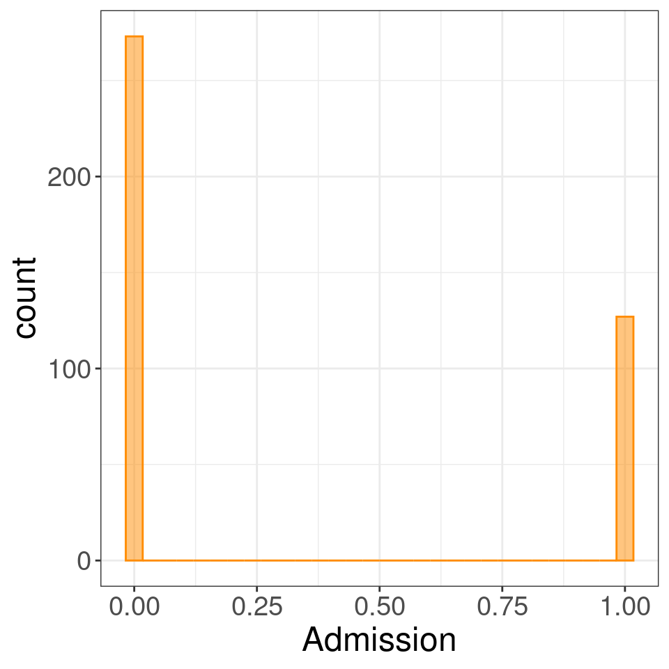

Question: How do we handle predicting a binary response?

## From binary to continous to likelihood

Answer: We predict the probability of the binary value being 1.

Let us say for each student \(S_i\) with *Admission* value \(A_i \in \{0,1\}\)

- we predict as \(\widehat{\rho}_i\) the probability of \(S_i\) being admitted

\[\widehat{\rho}_i = P(A_i=1)\]

Question: What is the likelihood of \(A_i\)?

Answer:

\[L_i = \left\{ \begin{array}{ccc}1 - \widehat{\rho}_i & & A_i=0 \\ \widehat{\rho}_i && A_i=1 \end{array} \right.\]

Question: What is the log-likelihood of \(A_i\)?

Answer: We take logs and use \(A_i\) as an indicator function

\[l_i = A_i \log(\widehat{\rho}_i) + (1 - A_i)\log(1 - \widehat{\rho}_i)\]

## Log-likelihood

Log-likelihood of all the data is then

\[l = \sum_i \left[A_i \log(\widehat{\rho}_i) + (1 - A_i)\log(1 - \widehat{\rho}_i)\right]\] We want to maximise this likelihood

- when we predict \(\widehat{\rho}\) from the covariates

When we regress

\[\rho \sim \text{GRE} + \text{GPA}\]

Question: What’s the problem here?

Answer: \(\rho\) has to be between 0 and 1

Question: How do we ensure this?

Answer: Transform it.

## Logit

A common choice is logit()

\[\mathrm{logit}(\rho) = \log\left(\frac{\rho}{1 - \rho}\right)\]

- rotational symmetry around \(\rho=\frac{1}{2}\)

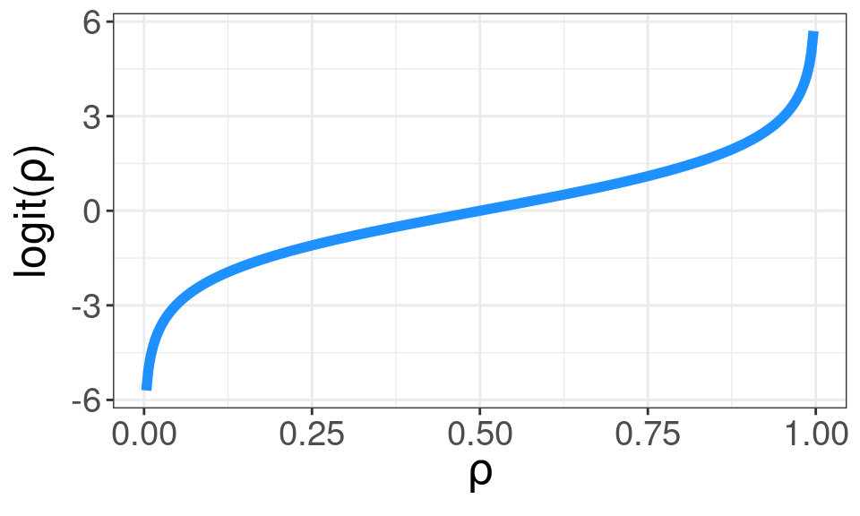

Question: What is the \(\frac{\rho}{1 - \rho}\) term?

Answer: \(\frac{\rho}{1 - \rho}\) is the odds.

Question: For \(\rho=\frac{1}{3}\) what are the odds?

Answer: \(\frac{1}{2}\). In betting odds, would be 2 to 1 (against)

## Logistic regression

We have a binary response variable: \(y\)

\(\to\) model underlying probability of being 1: \(\rho\)

\(\to\) transform to odds: \(\frac{\rho}{1 - \rho}\)

\(\to\) transform with log: \(\log\left(\frac{\rho}{1 - \rho}\right)\)

\(\to\) regress log odds on covariates:

\[\log\left(\frac{\rho}{1 - \rho}\right) = \beta_0 + \beta_1 x_1 + \ldots\]

To learn regression coefficients

\(\to\) predict log odds with regression

\(\to\) predicted probabilities \(\widehat{\rho}\)

\(\to\) maximise (log-)likelihood \(l\) numerically.

## Logistic regression in R

base R

With the glm(…) function, with family=“binomial”

```r
glm_fit <- glm(Admission ~ GRE + GPA, admiss_data, family="binomial")
glm_fit
```

```
##
## Call:  glm(formula = Admission ~ GRE + GPA, family = "binomial", data = admiss_data)
##
## Coefficients:
## (Intercept)          GRE          GPA
##     -4.9494       0.2691       0.7547
##
## Degrees of Freedom: 399 Total (i.e. Null);  397 Residual
## Null Deviance:       500
## Residual Deviance: 480.3     AIC: 486.3
```

- Deviance is like sum of squared residuals

## Regression coefficients

```
##               Estimate Std. Error   z value     Pr(>|z|)
## (Intercept) -4.9493781  1.0750929 -4.603675 4.151004e-06
## GRE          0.2690684  0.1057491  2.544403 1.094647e-02
## GPA          0.7546869  0.3195856  2.361455 1.820340e-02
```

Question: How much would the predicted odds of being *Admitted* change if we increase the *GRE* by 0.4 and the *GPA* by 0.2?

Answer: by a factor of exp(0.4 * 0.2691 + 0.2 * 0.7547) = 1.2951.

Remember we regress the log odds on the covariates

\[\log\left(\frac{\rho}{1 - \rho}\right) \sim \beta_0 + \beta_1 x_1 + \ldots\]

- change in the covariates
- leads to a linear change in log odds

Exponentiate the linear change

- multiplicative factor in the odds

## Predicted probabilities

Instead of odds, we can look at the predicted probabilities

```r
admiss_data$p_prob <- predict(glm_fit, type = "response")
```

```r
# plot of predicted probabilities
ggplot(admiss_data, aes(x=p_prob,
                         y = Admission)) +
  geom_point(colour = "dodgerblue",
             alpha = 0.5) +
# change axes labels
  xlab(expression(hat(rho)))
```

And for a particular “student”

```r
new_data <- data.frame(GRE = 5.5, GPA = 3.5)
```

[figure not shown]

```r
predict(glm_fit, type = "response", new_data)
```

```
##         1
## 0.3040474
```

## Bayesian logistic regression

Stan

For the Bayesian version with brms, similar syntax with family=bernoulli

```r
brm_logistic <- brm(Admission ~ GRE + GPA, family = bernoulli,
                prior = prior(student_t(3, 0, 1), class = "b"), # sets for both beta
                admiss_data) # run the model
```

Bernoulli is binomial with 1 trial, hence syntax (each subject is 1 row)

- for collated data need family=binomial and success | trials syntax
- \(\rightarrow\) see Exercises 8

Trace plots look good, as we would expect for a small model:

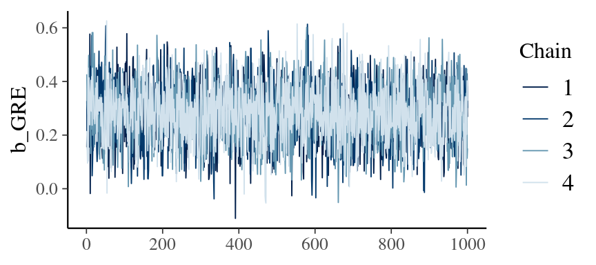

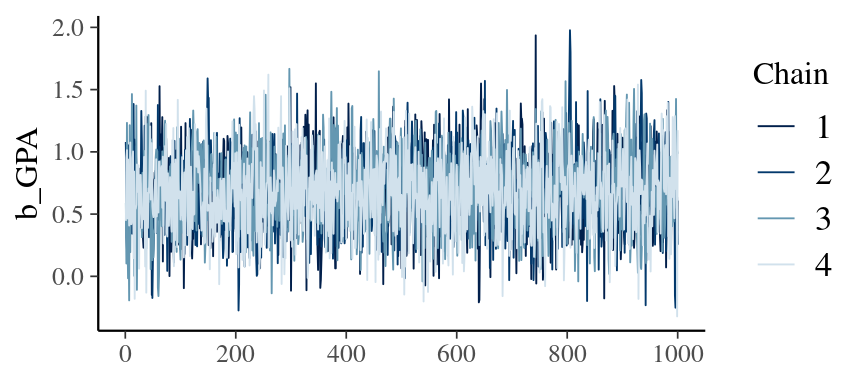

## Bayesian logistic regression

Stan

Model summary

```r
summary(brm_logistic)
```

```
##  Family: bernoulli
##   Links: mu = logit
## Formula: Admission ~ GRE + GPA
##    Data: admiss_data (Number of observations: 400)
##   Draws: 4 chains, each with iter = 2000; warmup = 1000; thin = 1;
##          total post-warmup draws = 4000
##
## Regression Coefficients:
##           Estimate Est.Error l-95% CI u-95% CI Rhat Bulk_ESS Tail_ESS
## Intercept    -4.80      1.08    -6.94    -2.69 1.00     4336     3212
## GRE           0.28      0.11     0.07     0.49 1.00     3221     3165
## GPA           0.69      0.31     0.08     1.30 1.00     3151     2999
##
## Draws were sampled using sampling(NUTS). For each parameter, Bulk_ESS
## and Tail_ESS are effective sample size measures, and Rhat is the potential
## scale reduction factor on split chains (at convergence, Rhat = 1).
```

- Coefficients away from 0
- logit-link function

## Regression coefficents and pp check

Stan

Visualise regression coefficients and posterior predictions

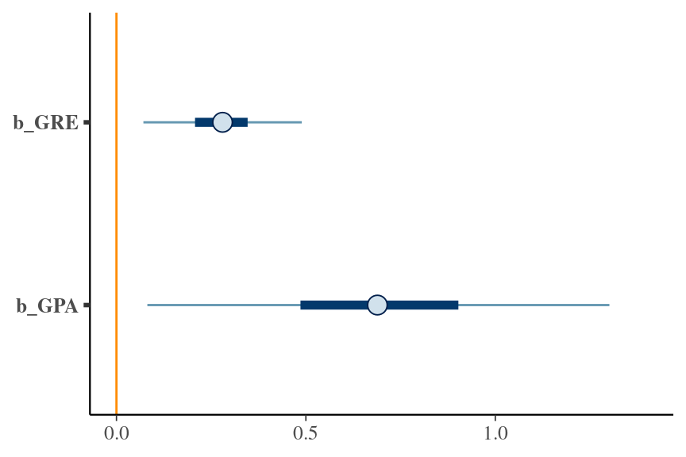

```r
mcmc_plot(brm_logistic, variable = "b_G",
    regex = TRUE, prob_outer = 0.95,
    type = "intervals") + xlim(0, 1.4) +
  geom_vline(xintercept = 0,
    color = "darkorange")
```

- higher scores consistent with higher success for *Admission*

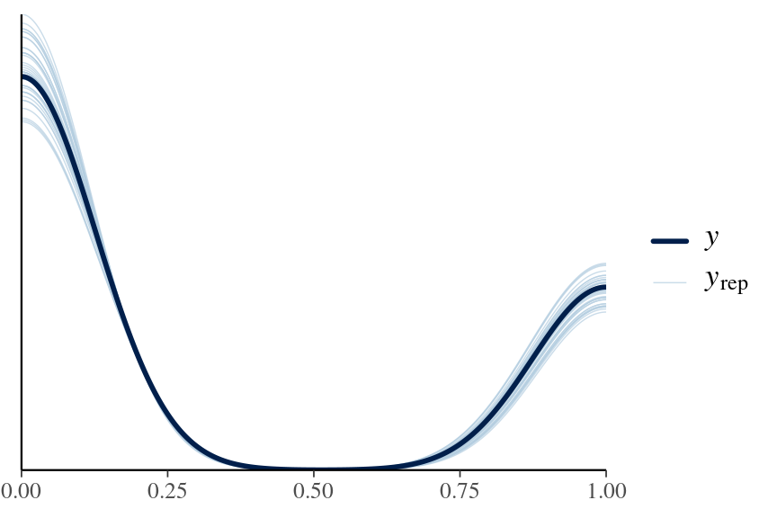

```r
# plot predictive check
pp_check(brm_logistic, ndraws = 40)
```

- Posterior samples in line with kernel density estimate

## Posterior probability of admission

Stan

Posterior predictions with posterior_predict and posterior_linpred

posterior_predict

- provides posterior samples in the outcome binary space

posterior_linpred

- provides posterior samples in the (logit-transformed) regression space with transform = FALSE
- or probability-space with transform = TRUE

For our particular “student”, let’s get samples in the probability space:

```r
new_data <- data.frame(GRE = 5.5, GPA = 3.5)
```

```r
new_data_prob <- posterior_linpred(brm_logistic,
                  new_data, transform = TRUE)
```

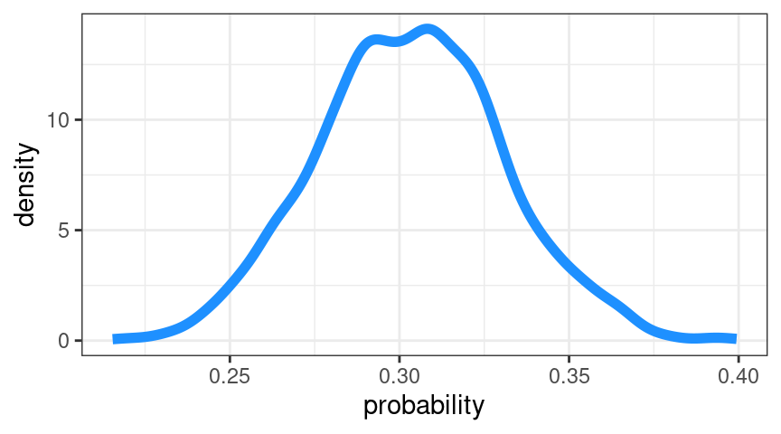

## Perfect premium

For both GRE and GPA

- some students get a perfect score

Let’s add to the data frame

```r
admiss_data %>% mutate(perfect = GRE == 8 &
  GPA == 4) -> admiss_data
head(admiss_data)
```

```
##   Admission GRE  GPA    p_prob perfect
## 1         0 3.8 3.61 0.2310310   FALSE
## 2         1 6.6 3.67 0.4003934   FALSE
## 3         1 8.0 4.00 0.5552525    TRUE
## 4         1 6.4 3.19 0.3057871   FALSE
## 5         0 5.2 2.93 0.2076762   FALSE
## 6         1 7.6 3.00 0.3451566   FALSE
```

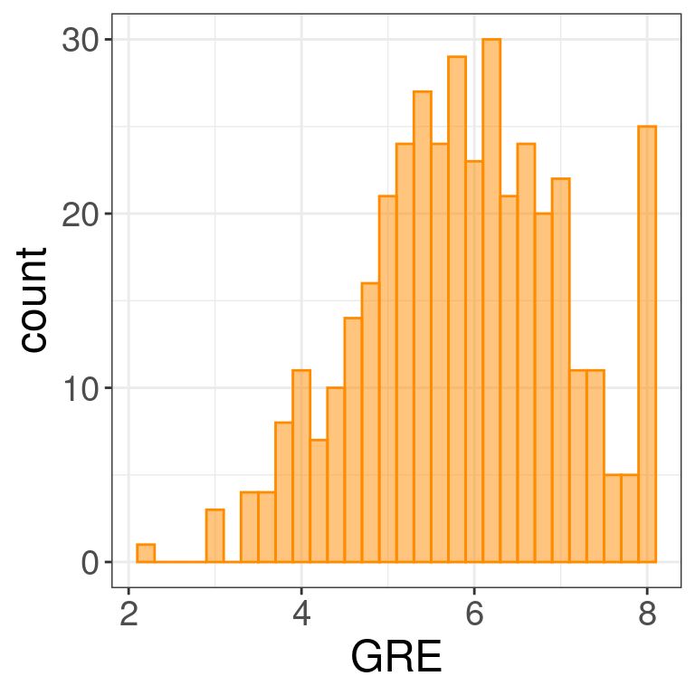

Question: Is there a premium for getting a perfect score?

## Bayesian premium estimate

Stan

Add *perfect* to the Bayesian model with brms

```r
brm_logist_prem <- brm(Admission ~ GRE + GPA + perfect, family = bernoulli, # add perfect
                   prior = prior(student_t(3, 0, 1), class = "b"), # sets for all beta
                   admiss_data) # run the model
```

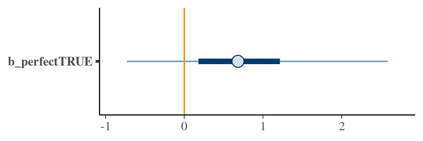

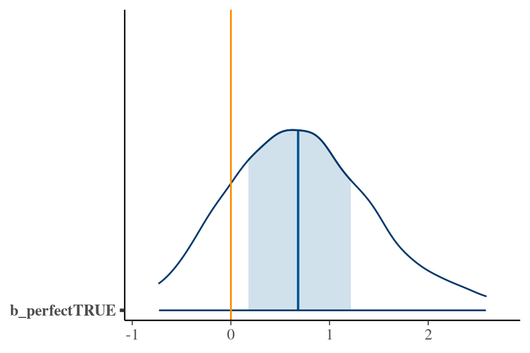

```r
mcmc_plot(brm_logist_prem, variable = "b_per",
    regex = TRUE, prob_outer = 0.95,
    type = "intervals") + geom_vline(
      xintercept = 0, color = "darkorange")
```

- Posterior of perfect score premium is typically positive, but a lot of uncertainty!

## Summary

For binary response variables

- logistic regression
- model log odds as a function of covariates

The exponential of the regression coefficients

- related to multiplicative change in the odds

With brms can again easily run Bayesian logistic regression

- with the same regression formula syntax bf(… ~ …)
- but with family=bernoulli

And a slightly different syntax for family=binomial

\(\rightarrow\) Exercises 8